# **BIG DATA AND CLOUD COMPUTING**

## **MODULE CODE**: KF7032

## **STUDENT ID**: W21054410

## **STUDENT NAME**: LUKE CHUGH

## **ASSIGNMENT TITLE**: DRUGS AND GUNS

## **1. INTRODUCTION**

There has been a lot of research on crime statistics [1] and recent technological advancements have made it lot more easier than ever before to draw insights from extracted crime data using big data analytics [2] which has helped both police and goverment authorities to take the right decisions in order to prevent the ongoing trend from continuing in future [3].

The "Drugs and Guns" project was motivated by this and aims to verify claims made in the "Ross Kemp and the Armed Police" ITV documentary on 6th September, 2018.

The claims were:

1. Violent crimes are increasing
2. There are more firearms incidents per head in Birmingham than anywhere else in the UK
3. Crimes involving firearms are closely associated with drug offenses

These claims were verified by utilizing "All crimes data" which was obtained by merging only "street" files from https://data.police.uk/data/. Since latitudes and longitudes in this dataset were anonymized, "LSOA" and "posttrans" datasets were utilized to decypher the location and include other relevant information required to verify the claims.

The datasets were stored in an Azure container named "lukechugh" and this notebook was run on an Azure instance. The data was stored in Pyspark and Pandas dataframes and were processed with Spark SQL. Storing the data in blob storage was preferred because it is faster than uploading all datasets each time runtime is restarted.

Advantages, disadvantages, and limitations of the chosen visualization, approaches, and statistical methods were explained where possible. The code includes comments and some cells were timed to evaluate efficiency of code. Pandas dataframes were used to convert the Spark dataframe for visualization with seaborn and pyplot.

## **2. COMPONENT SELECTION AND DATA PIPELINE IMPLEMENTATION CODE**

### **2.1 IMPORTING NECESSARY DEPENDENCIES**

```python
%%time
import re
import warnings
import datetime
import itertools
import numpy as np
import pandas as pd
import statsmodels.api as sm
from datetime import datetime
from pyspark.sql import Window
from pyspark import SparkFiles
import matplotlib.pyplot as plt
from pyspark.ml import Pipeline
from pyspark.sql.types import *
warnings.filterwarnings("ignore")
from pyspark.sql.functions import *
from pyspark.ml.linalg import Vectors
from pyspark.ml.stat import Summarizer
import seaborn as sns; sns.set_theme()
from pyspark.ml.stat import Correlation
from pyspark.mllib.stat import Statistics
from pyspark.ml.feature import VectorIndexer
from pyspark.ml.regression import GBTRegressor
from pyspark.ml.feature import VectorAssembler
from sklearn.metrics import mean_squared_error
from statsmodels.tsa.stattools import adfuller
from pyspark.sql import SparkSession, SQLContext
from sklearn.linear_model import LinearRegression
from sklearn.preprocessing import PolynomialFeatures
from pyspark.ml.evaluation import RegressionEvaluator
from pyspark.ml.regression import RandomForestRegressor
```

```
CPU times: user 1.69 s, sys: 374 ms, total: 2.07 s
Wall time: 3.65 s
```

### **2.2 STARTING SPARK SESSION**

```python
spark = SparkSession.builder.appName("Python Spark SQL").config("spark.some.config.option", "some-value").getOrCreate()
```

### **2.3 PATHS FOR DATASETS**

The following cell imports the file path of blob storage SAS urls in spark context

```python
# All Crimes
all_crimes_url = "https://lukechugh.blob.core.windows.net/data/all_crimes21_hdr.txt.gz"
spark.sparkContext.addFile(all_crimes_url)
all_crimes_path  = "file://" + SparkFiles.get('all_crimes21_hdr.txt.gz')

# Posttrans
posttrans_url = "https://lukechugh.blob.core.windows.net/data/posttrans.csv"
spark.sparkContext.addFile(posttrans_url)
posttrans_path  = "file://" + SparkFiles.get('posttrans.csv')

# LSOA
lsoa_url = "https://lukechugh.blob.core.windows.net/data/LSOA.csv"
spark.sparkContext.addFile(lsoa_url)
lsoa_path = "file://" + SparkFiles.get('LSOA.csv')
```

### **2.4 DEFINING SCHEMAS AND CREATING DATAFRAMES**

Dataframes are being produced in this part. To ensure that the appropriate data types were being used, I made the choice to declare the schema structure. Also, the column names are being enforced using the schemas so that I will not have to rename all the columns for all the dataframes. Also, by manual supervision of the CSV files, nullability for some of the columns were set to be true while defining the schemas.

The following schemas were used to insert these files into a dataframe. The header was set to true so that the first line was used as a header . Irrelevant columns were dropped after dataframes with their corresponding schemas were created in order to make queries using them a little faster and make it easier to display them.

```python
all_crimes_schema = StructType(
    [StructField("crime_id", StringType(), True),
     StructField("month", StringType(), False),
     StructField("reported_by", StringType(), False),
     StructField("falls_within", StringType(), False),
     StructField("longitude", DoubleType(), False),
     StructField("latitude", DoubleType(), False),
     StructField("location", StringType(), False),
     StructField("lsoa_code", StringType(), False),
     StructField("lsoa_name", StringType(), False),
     StructField("crime_type", StringType(), False),
     StructField("outcome", StringType(), True),
     StructField("context", StringType(), True),
     ])

posttrans_schema = StructType(
    [StructField("post_code", StringType(), False),
     StructField("long", DoubleType(), False),
     StructField("lat", DoubleType(), False),
     ])

lsoa_schema = StructType(
    [StructField("date", StringType(), False),
     StructField("geography", StringType(), False),
     StructField("geography_code", StringType(), False),
     StructField("rural/urban", StringType(), False),
     StructField("total_residents", IntegerType(), False),
     StructField("male_residents", IntegerType(), False),
     StructField("female_residents", IntegerType(), False),
     StructField("household_residents", IntegerType(), False),
     StructField("communal_residents", IntegerType(), False),
     StructField("school_students", IntegerType(), False),
     StructField("area(hectares)", DoubleType(), False),
     StructField("people/hectare", StringType(), False),
     ])
```

### **2.5 CREATING DATAFRAMES**

```python
# posttrans csv to pyspark dataframe
posttrans = spark.read.csv(posttrans_path, header = True, schema = posttrans_schema)
# lsoa csv to pyspark dataframe
lsoa_df = spark.read.csv(lsoa_path, header = True, schema = lsoa_schema)
# all crimes txt to pyspark dataframe
df = spark.read.csv(all_crimes_path, header = True, schema = all_crimes_schema)
```

### **2.6 DROPPING IRRELEVANT COLUMNS FROM DATAFRAMES**

```python
%%time

drop_from_all_crimes = ["crime_id", "context", "reported_by", "falls_within", "location"]

drop_from_postcodes = ["lat","long","district","county", "inuse?", "easting", "northing", "grid_ref", "ward", "ward_code",
                       "country", "country_code", "constituency", "introduced", "terminated", "parish", "national_park",
                       "lowerlayersuperoutputarea","population","households","built_up_area","built_up_sub_division",
                       "rural/urban","region","altitude"]

drop_from_lsoa = ["date","rural/urban", "male_residents", "female_residents","household_residents",
                  "communal_residents","school_students","area(hectares)","people/hectare","geography_code"]

df = df.drop(*drop_from_all_crimes)
lsoa_df = lsoa_df.drop(*drop_from_lsoa)
```

```
CPU times: user 7.36 ms, sys: 0 ns, total: 7.36 ms
Wall time: 166 ms
```

## **3. DATA EXTRACTION AND FILTERING**

### **3.1 REMOVING DUPLICATE ROWS AND TRANSFORMING THE "lsoa_name" & "geography" COLUMN**

16,279,225 duplicate rows were removed from all crimes. The "lsoa_name" and "geography" columns were transformed to remove alphanumeric substrings like "015C" and "001A" from each lsoa_city/geography. This was necessary to generate larger areas for data to be summed/counted for claim 2. The transformation was achieved using the "trim_lsoa" function, which uses regular expressions to remove the irrelevant substrings and strip empty spaces from the resulting string. This resulted in 349 and 348 unique county names in lsoa_city and geography respectively.

```python
%%time
# lsoa_name before transformation
df.show(5,False)
```

```
+-------+---------+---------+---------+---------------------------------+---------------------+-------+
|month  |longitude|latitude |lsoa_code|lsoa_name                        |crime_type           |outcome|
+-------+---------+---------+---------+---------------------------------+---------------------+-------+
|2010-12|-0.8056  |51.819143|E01017662|Aylesbury Vale 015C              |Other crime          |null   |
|2010-12|-2.494366|51.418169|E01014399|Bath and North East Somerset 001A|Anti-social behaviour|null   |
|2010-12|-2.511927|51.409435|E01014399|Bath and North East Somerset 001A|Anti-social behaviour|null   |
|2010-12|-2.511571|51.414895|E01014399|Bath and North East Somerset 001A|Anti-social behaviour|null   |
|2010-12|-2.511927|51.409435|E01014399|Bath and North East Somerset 001A|Anti-social behaviour|null   |
+-------+---------+---------+---------+---------------------------------+---------------------+-------+
only showing top 5 rows

CPU times: user 1.81 ms, sys: 994 µs, total: 2.8 ms
Wall time: 245 ms
```

```python
%%time
# showing the distinct crime type in all crimes
df.select("crime_type").distinct().show(truncate=False)
```

```
+----------------------------+
|crime_type                  |
+----------------------------+
|Bicycle theft               |
|Public order                |
|Drugs                       |
|Public disorder and weapons |
|Other crime                 |
|Robbery                     |
|Criminal damage and arson   |
|Theft from the person       |
|Shoplifting                 |
|Burglary                    |
|Violent crime               |
|Other theft                 |
|Possession of weapons       |
|Violence and sexual offences|
|Vehicle crime               |
|Anti-social behaviour       |
+----------------------------+

CPU times: user 1.13 s, sys: 107 ms, total: 1.24 s
Wall time: 3min 12s
```

There were 16 unique crime types in all crimes

```python
%%time
# counting number of rows in orignal all crimes
df.count()
```

```
CPU times: user 632 ms, sys: 75.4 ms, total: 708 ms
Wall time: 1min 44s
```

```
65078250
```

```python
%%time
# counting number of unique rows in orignal all crimes
df.select("month","longitude","latitude","lsoa_code","lsoa_name","crime_type","outcome").distinct().count()
```

```
CPU times: user 3.97 s, sys: 511 ms, total: 4.48 s
Wall time: 11min 27s
```

```
48799025
```

```python
%%time

# defining a function to remove alphanumeric part of substring using regular expression
def trim_lsoa(string):
    return re.sub(r"\d\w","", str(string)).strip()

# defining a udf which will basically work as .apply(function) in python
function = udf(lambda string : trim_lsoa(string), StringType())

# df2 is the all_crimes dataset with transformed lsoa_name column
df2 = df.select("month","longitude","latitude","lsoa_code",function(col("lsoa_name")).alias("lsoa_city"),"crime_type","outcome")

# removing duplicate rows
all_crimes = df2.select("month","longitude","latitude","lsoa_code","lsoa_city","crime_type","outcome").distinct()

# all crimes with lsoa_city after transformation
all_crimes.show(5,False)
```

```
+-------+---------+---------+---------+---------+---------------------+-------+
|month  |longitude|latitude |lsoa_code|lsoa_city|crime_type           |outcome|
+-------+---------+---------+---------+---------+---------------------+-------+
|2016-01|-5.242988|50.028536|E01018904|Cornwall |Anti-social behaviour|null   |
|2020-06|-5.086691|50.050291|E01018920|Cornwall |Anti-social behaviour|null   |
|2014-02|-5.623461|50.073659|E01019005|Cornwall |Anti-social behaviour|null   |
|2015-10|-5.315086|50.083363|E01018906|Cornwall |Anti-social behaviour|null   |
|2015-02|-5.313347|50.087542|E01018907|Cornwall |Anti-social behaviour|null   |
+-------+---------+---------+---------+---------+---------------------+-------+
only showing top 5 rows

CPU times: user 7.07 s, sys: 1.07 s, total: 8.14 s
Wall time: 20min 8s
```

```python
%%time
# Counting unique lsoa_city names after transformation
all_crimes.select("lsoa_city").distinct().count()
```

```
CPU times: user 4.49 s, sys: 616 ms, total: 5.11 s
Wall time: 13min 23s
```

```
349
```

```python
%%time
# Transforming "geography" column in lsoa_df to remove alphanumeric substrings
lsoa = lsoa_df.select(function(col("geography")).alias("geography"),"total_residents")
lsoa.show(5,False)
```

```
+----------+---------------+
|geography |total_residents|
+----------+---------------+
|Darlington|2466           |
|Darlington|1383           |
|Darlington|2008           |
|Darlington|1364           |
|Darlington|1621           |
+----------+---------------+
only showing top 5 rows

CPU times: user 8.82 ms, sys: 0 ns, total: 8.82 ms
Wall time: 364 ms
```

```python
%%time
# Counting distinct geography names after transformation
lsoa.select("geography").distinct().count()
```

```
CPU times: user 27.9 ms, sys: 8.56 ms, total: 36.5 ms
Wall time: 2 s
```

```
348
```

### **3.2 TRANSFORMING THE "post_code" COLUMN**

To generate larger area to sum up data for claim 2, the "post_code" column was transformed to remove the second part of each postcode. This was done using the "trim_postcode" function, which splits each postcode on the space character and returns only the first part.

```python
%%time
# post codes before transformation
posttrans.show(5,False)
```

```
+---------+---------+---------+
|post_code|long     |lat      |
+---------+---------+---------+
|HP20 1BL |-0.8056  |51.819143|
|BS31 2BT |-2.494366|51.418169|
|BS31 2PJ |-2.511927|51.409435|
|BS31 2EG |-2.511571|51.414895|
|BS31 2LQ |-2.513308|51.409456|
+---------+---------+---------+
only showing top 5 rows
```

```python
%%time

# Defining a function to split post code on delimeter " " and then return the first part of the post code
def trim_postcode(string):
        return str(string).split(" ")[0]

# defining a udf which will basically work as .apply(function) in python
split_function = udf(lambda string: trim_postcode(string), StringType())

# transforming postcodes
trimmed_posttrans = posttrans.select(split_function(col("post_code")).alias("postcode"),"lat","long")

# posttrans with transformed postcodes
trimmed_posttrans.show(5,False)
```

```
+--------+---------+---------+
|postcode|lat      |long     |
+--------+---------+---------+
|HP20    |51.819143|-0.8056  |
|BS31    |51.418169|-2.494366|
|BS31    |51.409435|-2.511927|
|BS31    |51.414895|-2.511571|
|BS31    |51.409456|-2.513308|
+--------+---------+---------+
only showing top 5 rows

CPU times: user 17.4 ms, sys: 1.95 ms, total: 19.3 ms
Wall time: 736 ms
```

### **3.3 EXTRACTING VIOLENT CRIMES FROM ALL CRIMES AS TIME SERIES**

The following cell extracts only those instances from all crimes for which crime_type is either "Violent crime" or "Violent and sexual offences". Then total number of violent crimes were counted for each unique month by grouping all the instances by month. The resulting pyspark dataframe is converted to a Pandas DataFrame for time series analysis, with "month" as the index.

```python
%%time

# Filtering all_crimes to have just the violent crimes and counting number of violent crimes that happened in each month
all_crimes.createOrReplaceTempView("all_crimes_table")
violent_crimes_count = spark.sql('''
select
  month,
  count(month) as crimes_commited
from
  all_crimes_table
where
  crime_type = 'Violent crime' or crime_type = 'Violence and sexual offences'
group by
  month
order by
  month
''')

# converting violent_crimes_count pyspark dataframe to pandas dataframe for visualisations
violent_crimes = violent_crimes_count.toPandas()

# converting the month column string datatype to pandas datetime format
violent_crimes.month = pd.to_datetime(violent_crimes.month,format = '%Y-%m')

# setting the datetime formatted month as index of this pandas dataframe
violent_crimes.set_index(violent_crimes.month,inplace=True)

# showing the first 5 rows of the pandas dataframe created
violent_crimes.head()
```

```
CPU times: user 2.12 s, sys: 348 ms, total: 2.47 s
Wall time: 5min 59s
```

| month | month | crimes_commited |
| --- | --- | --- |
| 2010-12-01 | 2010-12-01 | 39870 |
| 2011-01-01 | 2011-01-01 | 41345 |
| 2011-02-01 | 2011-02-01 | 39649 |
| 2011-03-01 | 2011-03-01 | 43247 |
| 2011-04-01 | 2011-04-01 | 44804 |

```python
%%time
# finding the number of distinct months in violent crimes
violent_crimes.month.nunique()
```

```
CPU times: user 670 µs, sys: 0 ns, total: 670 µs
Wall time: 681 µs
```

```
126
```

### **3.4 PRE-PROCESSING VIOLENT CRIME COUNTS FOR MACHINE LEARNING MODELS**

In this section, new features with crime counts for the previous 12 months were engineered which enabled ML models to learn the dependency between previous time steps. Nulls were dropped from the resulting dataframe and the "month" column (StringType) was split into two columns "year" and "month", as machine learning models could only work with numbers which is also why data types of the columns were converted to IntegerType.

```python
%%time
w = Window().partitionBy().orderBy(col("month"))
violent_crimes_count = violent_crimes_count.select("*", lag("crimes_commited").over(w).alias("lag1"))
violent_crimes_count = violent_crimes_count.select("*", lag("lag1").over(w).alias("lag2"))
violent_crimes_count = violent_crimes_count.select("*", lag("lag2").over(w).alias("lag3"))
violent_crimes_count = violent_crimes_count.select("*", lag("lag3").over(w).alias("lag4"))
violent_crimes_count = violent_crimes_count.select("*", lag("lag4").over(w).alias("lag5"))
violent_crimes_count = violent_crimes_count.select("*", lag("lag5").over(w).alias("lag6"))
violent_crimes_count = violent_crimes_count.select("*", lag("lag6").over(w).alias("lag7"))
violent_crimes_count = violent_crimes_count.select("*", lag("lag7").over(w).alias("lag8"))
violent_crimes_count = violent_crimes_count.select("*", lag("lag8").over(w).alias("lag9"))
violent_crimes_count = violent_crimes_count.select("*", lag("lag9").over(w).alias("lag10"))
violent_crimes_count = violent_crimes_count.select("*", lag("lag10").over(w).alias("lag11"))
violent_crimes_count = violent_crimes_count.select("*", lag("lag11").over(w).alias("lag12"))
violent_crimes_count.select("month","lag1","lag2","lag3","lag4","lag5","lag6","lag7","lag8","lag9","lag10","lag11","lag12","crimes_commited").show()
```

```
+-------+-----+-----+-----+-----+-----+-----+-----+-----+-----+-----+-----+-----+---------------+
|  month| lag1| lag2| lag3| lag4| lag5| lag6| lag7| lag8| lag9|lag10|lag11|lag12|crimes_commited|
+-------+-----+-----+-----+-----+-----+-----+-----+-----+-----+-----+-----+-----+---------------+
|2010-12| null| null| null| null| null| null| null| null| null| null| null| null|          39870|
|2011-01|39870| null| null| null| null| null| null| null| null| null| null| null|          41345|
|2011-02|41345|39870| null| null| null| null| null| null| null| null| null| null|          39649|
|2011-03|39649|41345|39870| null| null| null| null| null| null| null| null| null|          43247|
|2011-04|43247|39649|41345|39870| null| null| null| null| null| null| null| null|          44804|
|2011-05|44804|43247|39649|41345|39870| null| null| null| null| null| null| null|          44528|
|2011-06|44528|44804|43247|39649|41345|39870| null| null| null| null| null| null|          44039|
|2011-07|44039|44528|44804|43247|39649|41345|39870| null| null| null| null| null|          45941|
|2011-08|45941|44039|44528|44804|43247|39649|41345|39870| null| null| null| null|          43612|
|2011-09|43612|45941|44039|44528|44804|43247|39649|41345|39870| null| null| null|          41586|
|2011-10|41586|43612|45941|44039|44528|44804|43247|39649|41345|39870| null| null|          42963|
|2011-11|42963|41586|43612|45941|44039|44528|44804|43247|39649|41345|39870| null|          40958|
|2011-12|40958|42963|41586|43612|45941|44039|44528|44804|43247|39649|41345|39870|          41954|
|2012-01|41954|40958|42963|41586|43612|45941|44039|44528|44804|43247|39649|41345|          46375|
|2012-02|46375|41954|40958|42963|41586|43612|45941|44039|44528|44804|43247|39649|          42733|
|2012-03|42733|46375|41954|40958|42963|41586|43612|45941|44039|44528|44804|43247|          50344|
|2012-04|50344|42733|46375|41954|40958|42963|41586|43612|45941|44039|44528|44804|          46192|
|2012-05|46192|50344|42733|46375|41954|40958|42963|41586|43612|45941|44039|44528|          51503|
|2012-06|51503|46192|50344|42733|46375|41954|40958|42963|41586|43612|45941|44039|          49099|
|2012-07|49099|51503|46192|50344|42733|46375|41954|40958|42963|41586|43612|45941|          51707|
+-------+-----+-----+-----+-----+-----+-----+-----+-----+-----+-----+-----+-----+---------------+
only showing top 20 rows

CPU times: user 2.08 s, sys: 307 ms, total: 2.39 s
Wall time: 6min 11s
```

```python
%%time

# dropping nulls from violent crimes
violent_crimes_count = violent_crimes_count.na.drop()

# This function extracts year from month column by splitting the month column on delimeter "-" and taking the first part (year)
def strip_year(string):
        return str(string).split("-")[0]

# This function extracts month from month column by splitting the month column on delimeter "-" and taking the second part (month)
def strip_month(string):
        return str(string).split("-")[1]

# defining udfs for both extracting year and extracting month which will basically work as .apply(functions)
extract_year = udf(lambda string: strip_year(string), StringType())
extract_month = udf(lambda string: strip_month(string), StringType())

# creating lagged features of crime counts of previous 12 months so that models can learn time dependency between time steps
splitted_violent_crimes_count = violent_crimes_count.select(extract_year(col("month")).alias("year"),extract_month(col("month")).alias("month"),"lag1",
                                                          "lag2","lag3","lag4","lag5","lag6","lag7","lag8","lag9","lag10","lag11","lag12","crimes_commited")
splitted_violent_crimes_count.show(5,False)
```

```
+----+-----+-----+-----+-----+-----+-----+-----+-----+-----+-----+-----+-----+-----+---------------+
|year|month|lag1 |lag2 |lag3 |lag4 |lag5 |lag6 |lag7 |lag8 |lag9 |lag10|lag11|lag12|crimes_commited|
+----+-----+-----+-----+-----+-----+-----+-----+-----+-----+-----+-----+-----+-----+---------------+
|2011|12   |40958|42963|41586|43612|45941|44039|44528|44804|43247|39649|41345|39870|41954          |
|2012|01   |41954|40958|42963|41586|43612|45941|44039|44528|44804|43247|39649|41345|46375          |
|2012|02   |46375|41954|40958|42963|41586|43612|45941|44039|44528|44804|43247|39649|42733          |
|2012|03   |42733|46375|41954|40958|42963|41586|43612|45941|44039|44528|44804|43247|50344          |
|2012|04   |50344|42733|46375|41954|40958|42963|41586|43612|45941|44039|44528|44804|46192          |
+----+-----+-----+-----+-----+-----+-----+-----+-----+-----+-----+-----+-----+-----+---------------+
only showing top 5 rows

CPU times: user 2.22 s, sys: 253 ms, total: 2.47 s
Wall time: 6min 24s
```

```python
%%time

# changing the data type of all the columns to integer types because models only understand numbers
splitted_violent_crimes_count = splitted_violent_crimes_count.withColumn("year",col("year").cast(IntegerType()))\
                                .withColumn("month",col("month").cast(IntegerType()))\
                                .withColumn("lag1",col("lag1").cast(IntegerType()))\
                                .withColumn("lag2",col("lag2").cast(IntegerType()))\
                                .withColumn("lag3",col("lag3").cast(IntegerType()))\
                                .withColumn("lag4",col("lag4").cast(IntegerType()))\
                                .withColumn("lag5",col("lag5").cast(IntegerType()))\
                                .withColumn("lag6",col("lag6").cast(IntegerType()))\
                                .withColumn("lag7",col("lag7").cast(IntegerType()))\
                                .withColumn("lag8",col("lag8").cast(IntegerType()))\
                                .withColumn("lag9",col("lag9").cast(IntegerType()))\
                                .withColumn("lag10",col("lag10").cast(IntegerType()))\
                                .withColumn("lag11",col("lag11").cast(IntegerType()))\
                                .withColumn("lag12",col("lag12").cast(IntegerType()))\
                                .withColumn("crimes_commited",col("crimes_commited").cast(IntegerType()))

splitted_violent_crimes_count.printSchema()
```

```
root
 |-- year: integer (nullable = true)
 |-- month: integer (nullable = true)
 |-- lag1: integer (nullable = true)
 |-- lag2: integer (nullable = true)
 |-- lag3: integer (nullable = true)
 |-- lag4: integer (nullable = true)
 |-- lag5: integer (nullable = true)
 |-- lag6: integer (nullable = true)
 |-- lag7: integer (nullable = true)
 |-- lag8: integer (nullable = true)
 |-- lag9: integer (nullable = true)
 |-- lag10: integer (nullable = true)
 |-- lag11: integer (nullable = true)
 |-- lag12: integer (nullable = true)
 |-- crimes_commited: integer (nullable = false)

CPU times: user 33.4 ms, sys: 1.5 ms, total: 34.9 ms
Wall time: 296 ms
```

## **3.5 EXTRACTING FIREARM INCIDENTS FROM ALL CRIMES**

```python
%%time
# The following query selects only those instances from all_crimes data which belong to firearm incidents
# where the crime_type is "Possession of weapons" and the outcome is "Offender sent to prison."
all_crimes.createOrReplaceTempView("all_crimes_table")
firearm_incidents = spark.sql('''
select
  *
from
  all_crimes_table
where
  crime_type = 'Possession of weapons' and outcome = 'Offender sent to prison'
''')

# showing the first 20 rows of the firearm_incidents dataframe
firearm_incidents.show(truncate=False)
```

```
+-------+---------+---------+---------+----------------------+---------------------+-----------------------+
|month  |longitude|latitude |lsoa_code|lsoa_city             |crime_type           |outcome                |
+-------+---------+---------+---------+----------------------+---------------------+-----------------------+
|2013-08|-0.099933|51.462222|E01003073|Lambeth               |Possession of weapons|Offender sent to prison|
|2013-10|-1.481492|52.922083|E01013479|Derby                 |Possession of weapons|Offender sent to prison|
|2013-12|-0.087542|51.552621|E01002779|Islington             |Possession of weapons|Offender sent to prison|
|2014-02|-1.47481 |53.363776|E01008112|Sheffield             |Possession of weapons|Offender sent to prison|
|2014-04|-1.544785|53.796287|E01033010|Leeds                 |Possession of weapons|Offender sent to prison|
|2014-05|-2.801155|54.049022|E01033071|Lancaster             |Possession of weapons|Offender sent to prison|
|2014-07|-1.901388|52.515216|E01009051|Birmingham            |Possession of weapons|Offender sent to prison|
|2014-08|-3.523952|50.729483|E01020020|Exeter                |Possession of weapons|Offender sent to prison|
|2014-08|-1.701887|54.639354|E01020897|County Durham         |Possession of weapons|Offender sent to prison|
|2014-10|-0.544594|53.220821|E01026178|Lincoln               |Possession of weapons|Offender sent to prison|
|2014-11|-0.102745|51.611201|E01001394|Enfield               |Possession of weapons|Offender sent to prison|
|2014-11|-0.197244|51.472202|E01001922|Hammersmith and Fulham|Possession of weapons|Offender sent to prison|
|2014-11|-0.067582|51.603236|E01002034|Haringey              |Possession of weapons|Offender sent to prison|
|2014-12|0.083768 |51.576321|E01003645|Redbridge             |Possession of weapons|Offender sent to prison|
|2014-12|-1.94679 |52.453358|E01009075|Birmingham            |Possession of weapons|Offender sent to prison|
|2015-03|-3.54011 |50.494676|E01015252|Torbay                |Possession of weapons|Offender sent to prison|
|2015-04|-1.146513|53.507068|E01007534|Doncaster             |Possession of weapons|Offender sent to prison|
|2015-06|-2.684404|53.698851|E01025433|South Ribble          |Possession of weapons|Offender sent to prison|
|2015-07|-0.774047|51.575927|E01017891|Wycombe               |Possession of weapons|Offender sent to prison|
|2015-08|-3.206449|51.472366|W01001711|Cardiff               |Possession of weapons|Offender sent to prison|
+-------+---------+---------+---------+----------------------+---------------------+-----------------------+
only showing top 20 rows

CPU times: user 905 ms, sys: 79.4 ms, total: 984 ms
Wall time: 2min 54s
```

```python
%%time
# Filtering the rows with nulls in firearm_incidents dataframe
firearm_incidents.select([count(when(isnan(c) | col(c).isNull(),c)).alias(c) for c in firearm_incidents.columns]).show()
```

```
+-----+---------+--------+---------+---------+----------+-------+
|month|longitude|latitude|lsoa_code|lsoa_city|crime_type|outcome|
+-----+---------+--------+---------+---------+----------+-------+
|    0|       68|      68|       68|        0|         0|      0|
+-----+---------+--------+---------+---------+----------+-------+

CPU times: user 932 ms, sys: 102 ms, total: 1.03 s
Wall time: 3min
```

```python
%%time
# Filtering the rows where lsoa city is None
firearm_incidents.where(col('lsoa_city')=='None').count()
```

```
CPU times: user 1.52 s, sys: 171 ms, total: 1.69 s
Wall time: 3min 10s
```

```
68
```

lsoa_city is not showing "null" because it is "None" as this column was parsed as a string and then transformed.

This means that number of nulls for latitude, longitude and lsoa_code is the same.

### **3.6 EXTRACTING DRUG OFFENCES FROM ALL CRIMES**

```python
%%time
# The following query selects only those instances from all_crimes data for which the crime_type is "Drugs"
all_crimes.createOrReplaceTempView("all_crimes_table")
drug_offences = spark.sql('''
select
  *
from
  all_crimes_table
where
  crime_type = 'Drugs'
''')

# showing the first 20 rows of the firearm_incidents dataframe
drug_offences.show(truncate=False)
```

```
+-------+---------+---------+---------+-------------------+----------+-------+
|month  |longitude|latitude |lsoa_code|lsoa_city          |crime_type|outcome|
+-------+---------+---------+---------+-------------------+----------+-------+
|2011-09|-2.661301|51.500222|E01014638|Bristol            |Drugs     |null   |
|2011-09|-0.457128|52.120188|E01017472|Bedford            |Drugs     |null   |
|2011-09|0.468652 |51.7365  |E01033141|Chelmsford         |Drugs     |null   |
|2011-09|-1.54667 |54.5209  |E01012357|Darlington         |Drugs     |null   |
|2011-09|-1.61636 |54.9685  |E01033545|Newcastle upon Tyne|Drugs     |null   |
|2011-09|-0.077935|51.514281|E01032739|City of London     |Drugs     |null   |
|2011-09|-1.238947|54.641869|E01011968|Hartlepool         |Drugs     |null   |
|2011-09|-3.556096|54.645044|E01019121|Allerdale          |Drugs     |null   |
|2011-09|-3.539782|54.59883 |E01019269|Copeland           |Drugs     |null   |
|2011-09|-3.589227|54.549198|E01019280|Copeland           |Drugs     |null   |
|2011-09|-2.680329|54.291838|E01019394|South Lakeland     |Drugs     |null   |
|2011-09|-1.476391|52.928201|E01013523|Derby              |Drugs     |null   |
|2011-09|-1.92728 |50.699963|E01015406|Poole              |Drugs     |null   |
|2011-09|-3.992778|51.884092|W01000677|Carmarthenshire    |Drugs     |null   |
|2011-09|-4.229685|51.736201|W01000695|Carmarthenshire    |Drugs     |null   |
|2011-09|-3.096744|52.736527|W01000457|Powys              |Drugs     |null   |
|2011-09|-2.169857|53.477013|E01005108|Manchester         |Drugs     |null   |
|2011-09|-2.162324|53.630787|E01005494|Rochdale           |Drugs     |null   |
|2011-09|-2.30289 |53.454746|E01006187|Trafford           |Drugs     |null   |
|2011-09|-1.31571 |51.061943|E01023264|Winchester         |Drugs     |null   |
+-------+---------+---------+---------+-------------------+----------+-------+
only showing top 20 rows

CPU times: user 1.06 s, sys: 140 ms, total: 1.2 s
Wall time: 3min 20s
```

## **4. DESIGN, DEVELOPMENT AND REASONING BEHIND USE OF MULTIPLE VISUALISATION METHODS, STATISTICS AND MACHINE LEARNING MODELS**

Polynomial regression was included in this section for visualising trend, but other models like SARIMAX were not included because they require statistical analysis like the AD-Fuller test before its own implementation and and evaluation measures like RMSE, which are discussed in the next section.

### **4.1 VIOLENT CRIMES ARE INCREASING, DECREASING OR ARE STABLE ?**

This section uses different visualisations to analyse trends in violent crimes.

**Polynomial Regression**

Polynomial regression can model non-linear relationships using a linear model by adding powers of each feature as new features, then training a linear model on these extended set of features. It was used by authors of [4-6] to visualise crime trends in different parts of the world. Most of them used a 3 degree polynomial as it enabled them to **approximate the time series by fitting a curve** on top of the original time series, which smoothed fluctuations and made it easier to visualise the trend. In this case, a 5 degree polynomial was found to be the best fit for the given time series.

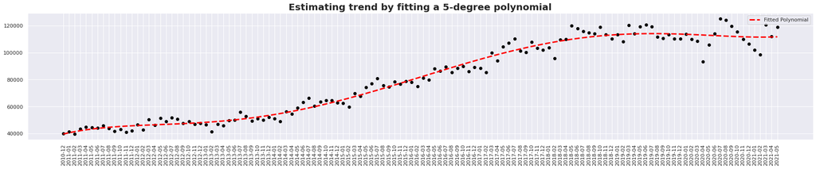

```
CPU times: user 3.76 s, sys: 471 ms, total: 4.23 s
Wall time: 4.16 s
```

```python
%%time
# setting size of the plot
plt.rcParams["figure.figsize"] = (30,5)
# Linear Regression object
linreg = LinearRegression()
# Linear Regression can only understand numbers and not pandas datetime formatted months
# There were 126 unique months from 2010-12 and 2021-05, creating dummy months and reshaping it to a matrix
x = np.arange(0,126).reshape(-1,1)
y = violent_crimes.crimes_commited
# Generating 5 degree polynomial features by fitting it on x (dummies for months)
poly_features = PolynomialFeatures(degree=5,include_bias=False)
x_poly = poly_features.fit_transform(x)
# Predicting corresponding y values for 5 degree polynomial x features to make it polynomial regression
linreg.fit(x_poly,y)
y_vals = linreg.predict(x_poly)
# scatter orignal time series data with x as dummy months and y as crime counts
plt.scatter(x,y,color='black')
# plot the fitted 5 degree fitted polynomial with respect to dummy months
plt.plot(x,y_vals,linestyle="--",linewidth=3,color="red",label="Fitted Polynomial")
# replace dummy months with orignal months and only keep the year and the month from pandas datetime format
plt.xticks(np.arange(0,126),violent_crimes.month.apply(lambda x: x.strftime('%Y-%m')),rotation=90)
# setting and formatting title
plt.title("Estimating trend by fitting a 5-degree polynomial",fontsize=20,fontweight="bold")
# setting the legend
plt.legend()
plt.show()
```

**KDE Plot**

A bivariate KDE plot/contour plot depicts the joint probability density between two continuous variables with the use of contour lines which are basically the 2D projections of a 3D bell curve. It was used by authors of [7-10] to determine the crime density in different regions of different countries. Contour lines connect points of equal value and can provide a clear and intuitive **visualisation of trends** in data by showing how the joint probability density of two continuous variables change over a two-dimensional space. If the contour lines are closely spaced, it could indicate that the probability of the two variables taking on those values is high, while if the contour lines are widely spaced, it could indicate that the probability is low.

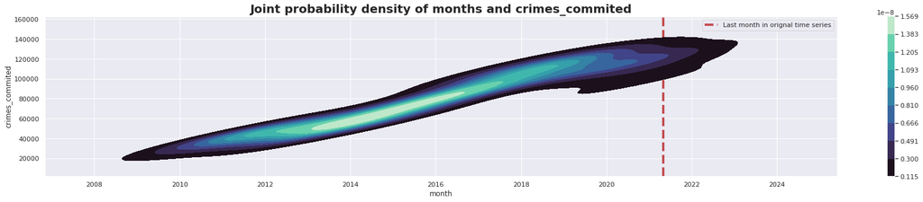

```
CPU times: user 667 ms, sys: 123 ms, total: 790 ms
Wall time: 837 ms
```

```python
%%time
# setting plot size
plt.rcParams["figure.figsize"] = (30,5)
# setting title
plt.title("Joint probability density of months and crimes_commited",fontsize=20,fontweight="bold")
# plotting a vertical line indicating the last month in original time series
plt.axvline(x=datetime.strptime("2021-05","%Y-%m"),linewidth=4, color='r',zorder=1,linestyle="--",label="Last month in orignal time series")
# setting up the label
plt.legend()
# plotting bivariate KDE plot
sns.kdeplot(data=violent_crimes, x="month",y="crimes_commited",shade=True,cmap="mako",cbar=True,zorder=2,label="KDE plot")
plt.show()
```

**Bar Plot**

To visualise crime statistics and analyse the trend, the authors of [11-14] implemented barplot as it enabled them to compare all the months based on crime counts. The height of each bar would represent the crime count for different months over time, and the trend in crimes can be seen by comparing the heights of the bars from one month to the next.

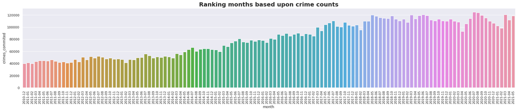

```
CPU times: user 4.42 s, sys: 434 ms, total: 4.85 s
Wall time: 4.8 s
```

```python
%%time
# setting figure size
plt.rcParams["figure.figsize"] = (30,5)
# rotating xticks by 90 degrees to prevent them from merging with each other
plt.xticks(rotation=90)
# setting and formatting title
plt.title("Ranking months based upon crime counts",fontsize=20,fontweight="bold")
# keeping only the month and year from month column and plotting months vs crime counts using barplot
sns.barplot(violent_crimes.month.apply(lambda x: x.strftime('%Y-%m')),violent_crimes.crimes_commited)
plt.show()
```

**Moving Average Plot**

A moving average plot is computed by calculating the rolling mean over a window size of certain months. Some of the authors of [15-17] used window size of 3 months whereas others used window size of 12 months to compute the rolling mean as it smooths out fluctuations, separates out random variations, and is less prone to false signals which makes it much more easier to illustrate overall pattern in data and visualise the underlying trend. As a result, one can expect to see a line chart with the average value of the data plotted at each point in time.

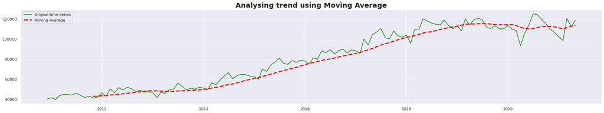

```
CPU times: user 311 ms, sys: 1.8 ms, total: 313 ms
Wall time: 323 ms
```

```python
%%time
# defining function for plotting moving average
def plot_moving_average(timeseries, title):
    plt.clf()
    # computing rolling mean of window size of every 12 months
    rolmean = pd.Series(timeseries).rolling(window=12).mean()
    # setting figure size
    fig, ax = plt.subplots(figsize=(30, 5))
    # setting and formatting title
    plt.title("Moving Average",fontsize=20,fontweight="bold")
    # plotting orignal time series
    ax.plot(timeseries, label= title,color='green')
    # plotting rolling mean
    ax.plot(rolmean,label='Moving Average',linestyle="--",linewidth=3,color="red")
    # plotting title
    plt.title("Analysing trend using Moving Average",fontsize=20,fontweight="bold")
    # setting legend
    ax.legend()
    plt.show()

pd.options.display.float_format = '{:.8f}'.format
plot_moving_average(violent_crimes['crimes_commited'],'Orignal time series')
```

**Interpretations:**

Unlike other visualisations, KDE plot forecasted the joint probability density beyond the last month (red line) in given time series. All four visualisations explicitly show that as we move along the x axis in the direction of future months, the crime counts increase. Overall, there has been an increasing trend from 2010-12 to 2021-05, **verifying claim 1 to be true**. However, from 2019 to 2021 the trend has been almost stable.

## **5. SELECTION APPLICATION AND REASONING BEHIND USE OF STATISTICAL ANALYSIS AND MULTIPLE EVALUATION MEASURES**

### **5.1 SEASONALITY**

The detrended time series was grouped by all **values** for each month and year, **averaged** to compute the seasonal component for that year, and **replicated** for all years in the original time series to obtain the seasonality.

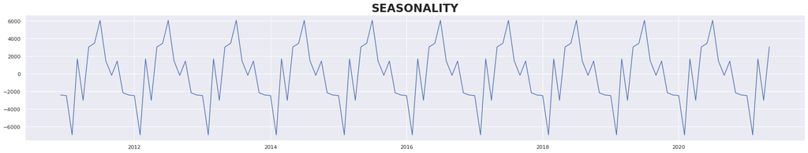

```
CPU times: user 282 ms, sys: 1.6 ms, total: 283 ms
Wall time: 321 ms
```

```python
%%time
# setting figure size
plt.rcParams["figure.figsize"] = (30,5)
# decomposing the orignal time series
decomposition = sm.tsa.seasonal_decompose(violent_crimes['crimes_commited'], model='additive',extrapolate_trend='freq')
# taking only the seasonal component from decomposition
seasonal = decomposition.seasonal
# setting and formatting title
plt.title("SEASONALITY", fontsize = 24, fontweight = 'bold')
plt.plot(seasonal)
plt.show()
```

The plot indicates that the given time series has a seasonal component that repeats every **12 months** and also shows that given time series has **additive seasonality** because the height and width of seasonal component doesn't changes with time. Since given time series has both a trend and seasonality, it is not stationary.

### **5.2 RESIDUALS**

A time series is assumed to be comprised of only trend and seasonality, so any other signals are considered as residuals which are obtained by removing the trend and seasonality from the original time series.

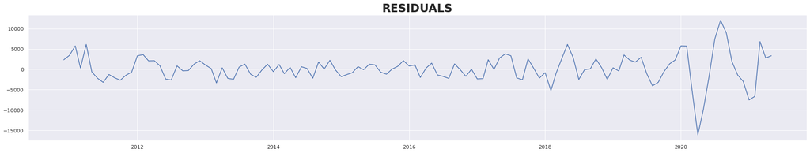

```
CPU times: user 274 ms, sys: 789 µs, total: 275 ms
Wall time: 278 ms
```

```python
%%time
# picking up only residuals from time series decomposition
residuals = decomposition.resid
# setting and formatting title
plt.title("RESIDUALS", fontsize = 24, fontweight = 'bold')
plt.plot(residuals)
plt.show()
```

### **5.3 AUGMENTED DICKY-FULLER TEST** [18]

Statistical models assume stationarity and their performance depends on this assumption which is why the given time series was made stationary by detrending and double differencing. It was detrended by subtracting the rolling mean and then dividing by rolling standard deviation of 12 months window. Then it's stationarity was tested using the augmented Dickey-Fuller test which is a hypothesis test where the null hypothesis is that the given time series is not stationary. If the test statistic is less than the critical value, we can reject the null hypothesis and say with confidence that the time series is stationary.

```python
%%time
# This cell shows that time series successfuly became stationary by detrending and double differencing

# detrending the time series by subtracting the rolling mean and dividing it by rolling standard deviation
y = violent_crimes['crimes_commited']
y_detrend =  (y - y.rolling(window=12).mean())/y.rolling(window=12).std()

# detrending and double differencing the time series to make it stationary
y_12lag_detrend =  y_detrend - 2*y_detrend.shift(12)

# defining a function to perform augmented dicky fuller test
def ADF_test(timeseries, dataDesc):
    print(' > Is the {} stationary ?'.format(dataDesc))
    dftest = adfuller(timeseries.dropna(), autolag='AIC')
    print('Test statistic = {:.3f}'.format(dftest[0]))
    print('P-value = {:.3f}'.format(dftest[1]))
    print('Critical values :')
    for k, v in dftest[4].items():
        print('\t{}: {} - The data is {} stationary with {}% confidence'.format(k, v, 'not' if v<dftest[0] else '', 100-int(k[:-1])))

# H0: Null hypothesis states that data is not stationary
# H1: Alternate Hypothesis states that data is stationary
ADF_test(y_12lag_detrend,'12 lag differenced de-trended data')
```

```
 > Is the 12 lag differenced de-trended data stationary ?
Test statistic = -5.020
P-value = 0.000
Critical values :
	1%: -3.4961490537199116 - The data is  stationary with 99% confidence
	5%: -2.8903209639580556 - The data is  stationary with 95% confidence
	10%: -2.5821223452518263 - The data is  stationary with 90% confidence
CPU times: user 11.8 ms, sys: 2.05 ms, total: 13.9 ms
Wall time: 58.9 ms
```

Since the test statistic is lower than the critical value for 1%, we can reject the null hypothesis and say that the **data is stationary with 99% confidence.**

### **5.4 MODEL TRAINING AND EVALUATION**

In this section models are being built to learn patterns in the given time series so that they can forecast the crime counts for the future. The ability of these models to forecast is evaluated qualitatively by plotting forecasted crime counts on top of orignal crime counts and quantitatively by computing RMSE between forecasted crime counts and orignal crime counts. Reason for using RMSE for evaluating regression-based models was that it penalizes forecasts that are far from the actual values more than those that are closer. RMSE was normalized by dividing it by the difference between the maximum and minimum values in the test data to account for the large scale of the values.

### **5.4.1 SARIMAX** [19]

Authors of [19-21] implemented SARIMAX to forecast crimes in different parts of the world because SARIMAX can model the next step in the sequence as a linear function of the differenced observations and residual errors, and can recognize the influence of adjacent points in time on one another. Also since, given time series had seasonality SARIMAX seemed appropriate for this use case.

### **5.4.2 FINDING OPTIMAL VALUES FOR ORDER AND SEASONAL ORDER**

```python
%%time
# dropping nulls from lagged detrended time series
y_12lag_detrend = y_12lag_detrend.to_frame().dropna()
# creating test, train and validation sets
y_to_train = y[:'2020-01-01']
y_to_test = y['2020-02-01':]

# Trying every single combination for p,d,q and P,D,Q with respect to AIC score to find the optimal values
# for order and seasonal order
p = d = q = range(0, 4)
seasonal_period = 12
pdq = list(itertools.product(p, d, q))
seasonal_pdq = [(x[0], x[1], x[2],seasonal_period) for x in list(itertools.product(p, d, q))]
for param in pdq:
    for param_seasonal in seasonal_pdq:
        try:
            mod =\
            sm.tsa.statespace.SARIMAX(y_to_train,
                                      order=param,
                                      seasonal_order=param_seasonal,
                                      enforce_invertibility=False)
            results = mod.fit(disp=False)
            print('ARIMA{}x{}12 - AIC:{}'.format(param, param_seasonal, results.aic))
        except Exception as ex:
            continue
```

```
ARIMA(0, 0, 0)x(0, 0, 0, 12)12 - AIC:2855.094132730982
ARIMA(0, 0, 0)x(0, 0, 1, 12)12 - AIC:2817.762392760036
ARIMA(0, 0, 0)x(0, 0, 2, 12)12 - AIC:2964.0149755060283
ARIMA(0, 0, 0)x(0, 0, 3, 12)12 - AIC:nan
ARIMA(0, 0, 0)x(0, 1, 0, 12)12 - AIC:2173.21929314057
ARIMA(0, 0, 0)x(0, 1, 1, 12)12 - AIC:2171.367393969294
ARIMA(0, 0, 0)x(0, 1, 2, 12)12 - AIC:2168.1126897389977
ARIMA(0, 0, 0)x(0, 1, 3, 12)12 - AIC:2176.7674716470565
ARIMA(0, 0, 0)x(0, 2, 0, 12)12 - AIC:1830.1973767509508
ARIMA(0, 0, 0)x(0, 2, 1, 12)12 - AIC:1830.0597762871537
ARIMA(0, 0, 0)x(0, 2, 2, 12)12 - AIC:3938.379810460173
ARIMA(0, 0, 0)x(0, 2, 3, 12)12 - AIC:1801.505327462684
ARIMA(0, 0, 0)x(0, 3, 0, 12)12 - AIC:2171.455355871851
ARIMA(0, 0, 0)x(0, 3, 1, 12)12 - AIC:2146.386743726683
ARIMA(0, 0, 0)x(0, 3, 2, 12)12 - AIC:nan
ARIMA(0, 0, 0)x(0, 3, 3, 12)12 - AIC:2007.9010771371775
ARIMA(0, 0, 0)x(1, 0, 0, 12)12 - AIC:2535.2754892948765
ARIMA(0, 0, 0)x(1, 0, 1, 12)12 - AIC:2420.520010465512
ARIMA(0, 0, 0)x(1, 0, 2, 12)12 - AIC:2428.034751127034
ARIMA(0, 0, 0)x(1, 1, 0, 12)12 - AIC:2200.5857803568056
ARIMA(0, 0, 0)x(1, 1, 1, 12)12 - AIC:2104.4121498751165
ARIMA(0, 0, 0)x(1, 1, 2, 12)12 - AIC:2093.880855869981
ARIMA(0, 0, 0)x(1, 1, 3, 12)12 - AIC:2075.289982783234
ARIMA(0, 0, 0)x(1, 2, 0, 12)12 - AIC:1830.3598889840378
ARIMA(0, 0, 0)x(1, 2, 1, 12)12 - AIC:1812.1619801371594
ARIMA(0, 0, 0)x(1, 2, 2, 12)12 - AIC:3875.2221549213014
ARIMA(0, 0, 0)x(1, 2, 3, 12)12 - AIC:1803.6394974150874
ARIMA(0, 0, 0)x(1, 3, 0, 12)12 - AIC:2285.146081047581
ARIMA(0, 0, 0)x(1, 3, 1, 12)12 - AIC:1928.1454803126749
ARIMA(0, 0, 0)x(1, 3, 3, 12)12 - AIC:1843.8807420435119
ARIMA(0, 0, 0)x(2, 0, 0, 12)12 - AIC:2396.8118549236256
ARIMA(0, 0, 0)x(2, 0, 1, 12)12 - AIC:2394.3860654688674
ARIMA(0, 0, 0)x(2, 0, 2, 12)12 - AIC:2405.2004148457677
ARIMA(0, 0, 0)x(2, 1, 0, 12)12 - AIC:2183.887164166612
ARIMA(0, 0, 0)x(2, 1, 1, 12)12 - AIC:2098.53846295382
ARIMA(0, 0, 0)x(2, 1, 2, 12)12 - AIC:2108.704065277986
ARIMA(0, 0, 0)x(2, 1, 3, 12)12 - AIC:2096.7352578349714
ARIMA(0, 0, 0)x(2, 2, 0, 12)12 - AIC:1812.8766309091452
ARIMA(0, 0, 0)x(2, 2, 1, 12)12 - AIC:1800.1554173274021
ARIMA(0, 0, 0)x(2, 2, 3, 12)12 - AIC:1801.0443851796367
```

[output cut: 3943 more lines]

```
ARIMA(3, 3, 3)x(3, 0, 3, 12)12 - AIC:2193.053335610309
ARIMA(3, 3, 3)x(3, 1, 0, 12)12 - AIC:1890.4883175178475
ARIMA(3, 3, 3)x(3, 1, 1, 12)12 - AIC:1892.4506845723715
ARIMA(3, 3, 3)x(3, 1, 2, 12)12 - AIC:7526.980538525164
ARIMA(3, 3, 3)x(3, 1, 3, 12)12 - AIC:1892.6028991944302
ARIMA(3, 3, 3)x(3, 2, 0, 12)12 - AIC:1700.1981473043943
ARIMA(3, 3, 3)x(3, 2, 1, 12)12 - AIC:1697.8881930319455
ARIMA(3, 3, 3)x(3, 2, 2, 12)12 - AIC:6676.509881298258
ARIMA(3, 3, 3)x(3, 2, 3, 12)12 - AIC:1701.7376032769964
ARIMA(3, 3, 3)x(3, 3, 0, 12)12 - AIC:1595.2849838882341
ARIMA(3, 3, 3)x(3, 3, 1, 12)12 - AIC:1620.2372675189638
ARIMA(3, 3, 3)x(3, 3, 2, 12)12 - AIC:1631.1208089719014
ARIMA(3, 3, 3)x(3, 3, 3, 12)12 - AIC:1635.0907784744668
CPU times: user 17h 1min 50s, sys: 12h 3min 19s, total: 1d 5h 5min 9s
Wall time: 7h 30min 17s
```

### **5.4.3 TRAINING SARIMAX**

SARIMAX was trained using the order and seasonal order obtained from previous cell and then model's result diagnostics were plotted.

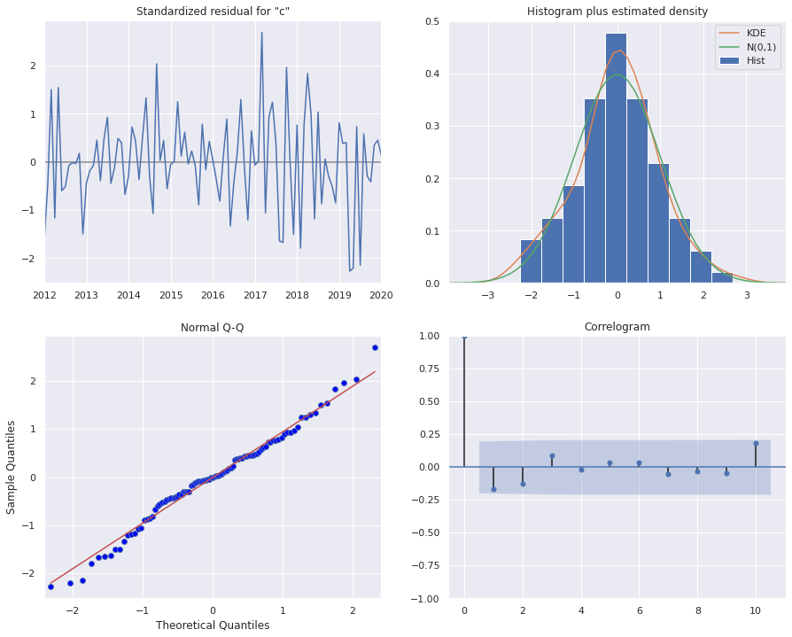

```
CPU times: user 10.9 s, sys: 7.69 s, total: 18.6 s
Wall time: 10.4 s
```

```python
%%time
order = (2, 1, 3)
seasonal_order = (3, 1, 2, 12)
# Fitting the model and plot the model diagnostics
model = sm.tsa.statespace.SARIMAX(y_to_train,
                            order=order,
                            seasonal_order=seasonal_order,
                            enforce_invertibility=False)
results = model.fit(disp=False)
results.plot_diagnostics(figsize=(15, 12))
plt.show()
```

The result diagnostics in this section shows that the residuals were stationary and normally distributed, indicating that SARIMAX fitted well on the training data.

### **5.4.4 EVALUATING SARIMAX**

To evaluate SARIMAX, predictions were made for the next 16 months to match months in test data. Then normalised RMSE was computed between the predicted mean of the forecasted crime counts and the actual crime counts in the test data.

```python
%%time
# Produce the forcasted tables to match the months in test data
pred_uc = results.get_forecast(steps=16)
pred_ci = pred_uc.conf_int()
pm = pred_uc.predicted_mean.reset_index()
pm.columns = ['Month','Predicted_Mean']
pci = pred_ci.reset_index()
pci.columns = ['Month','Lower Bound','Upper Bound']
final_table = pm.join(pci.set_index('Month'), on='Month')
final_table
```

```
CPU times: user 24.6 ms, sys: 1.41 ms, total: 26 ms
Wall time: 40.9 ms
```

|  | Month | Predicted_Mean | Lower Bound | Upper Bound |
| --- | --- | --- | --- | --- |
| 0 | 2020-02-01 | 149514.380516 | 141900.262742 | 157128.498290 |
| 1 | 2020-03-01 | 170477.849914 | 160249.484671 | 180706.215157 |
| 2 | 2020-04-01 | 163195.867068 | 150684.154585 | 175707.579551 |
| 3 | 2020-05-01 | 172270.157248 | 157678.542496 | 186861.772001 |
| 4 | 2020-06-01 | 173749.191713 | 157283.154774 | 190215.228651 |
| 5 | 2020-07-01 | 175314.512601 | 157201.407955 | 193427.617247 |
| 6 | 2020-08-01 | 164455.594400 | 144920.675938 | 183990.512862 |
| 7 | 2020-09-01 | 161236.555864 | 140470.021072 | 182003.090656 |
| 8 | 2020-10-01 | 168513.260965 | 146648.391823 | 190378.130106 |
| 9 | 2020-11-01 | 163273.334570 | 140381.991496 | 186164.677643 |
| 10 | 2020-12-01 | 162899.723607 | 139003.013864 | 186796.433351 |
| 11 | 2021-01-01 | 167025.255077 | 142114.398219 | 191936.111935 |
| 12 | 2021-02-01 | 158725.446394 | 130704.800262 | 186746.092526 |
| 13 | 2021-03-01 | 178866.681258 | 148230.454866 | 209502.907650 |
| 14 | 2021-04-01 | 172090.938685 | 138929.403923 | 205252.473446 |
| 15 | 2021-05-01 | 181202.354046 | 145640.734525 | 216763.973566 |

```python
y_to_test
```

```
month
2020-02-01    151260
2020-03-01    149773
2020-04-01    127901
2020-05-01    145837
2020-06-01    158701
2020-07-01    175562
2020-08-01    174980
2020-09-01    164204
2020-10-01    158725
2020-11-01    151251
2020-12-01    148517
2021-01-01    141414
2021-02-01    135101
2021-03-01    166668
2021-04-01    153789
2021-05-01    171614
Name: crimes_commited, dtype: int64
```

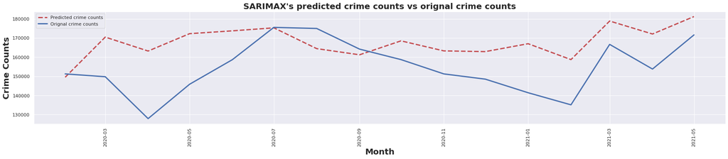

```python
# setting figure size
plt.figure(figsize=(30,5))
# setting and formatting the title
plt.title("SARIMAX's predicted crime counts vs orignal crime counts",fontsize=20,fontweight="bold")
# setting and formatting the x label
plt.xlabel("Month",fontsize=20,fontweight="bold")
# setting and formatting the y label
plt.ylabel("Crime Counts",fontsize=20,fontweight="bold")
# plotting the predicted values of crimes commited
plt.plot(final_table.Month, final_table.Predicted_Mean,linewidth=3,color='r',linestyle='--',label="Predicted crime counts")
# plotting the original values of crimes commited in test data
plt.plot(final_table.Month, y_to_test,linewidth=3,color='b', label="Orignal crime counts")
# rotating the xticks by 90 degrees so that they don't merge with each other
plt.xticks(rotation=90)
# setting the legend
plt.legend()
plt.show()
```

```python
%%time
# finding the normalised rmse between test data and forecasted predicted mean values
rmse = mean_squared_error(y_to_test, final_table['Predicted_Mean'])**0.5
print(f"Normalised RMSE = {rmse/(y_to_test.max()-y_to_test.min()):.2f}")
```

```
Normalised RMSE = 0.37
CPU times: user 1.64 ms, sys: 804 µs, total: 2.45 ms
Wall time: 2.25 ms
```

Both the line plot and normalised rmse of 0.37 indicate that there was significant deviation between the forecasted and orginal crime counts.

### **5.4.5 RANDOM FORESTS** [23]

Authors of [23-26] used Random Forests to forecast crimes in different parts of the world reason being that random forests trains multiple decision trees in parallel on **random samples of the training data** (bootstrapping) and produces an output by averaging the results of all trees in the forest which makes it less likely to overfit. Another advantage of Random Forest is that bootstrapping makes it robust to outliers and underperformance of any tree doesn't affect the overall performance.

```python
%%time
# using vector assembler to create a single feature which contains values of all other features
vecAssembler = VectorAssembler(inputCols=['year','month','lag1','lag2','lag3','lag4','lag5','lag6','lag7',
                                          'lag8','lag9','lag10','lag11','lag12'], outputCol="features")

# Splitting the whole pre-processed dataset into 80% train and 20% test data
(trainDF, testDF) = splitted_violent_crimes_count.randomSplit([.8, .2])
# defining random forests model with inputs as features and labels
rf = RandomForestRegressor(featuresCol="features",labelCol='crimes_commited')
# creating pipeline of vector assembler and random forest model
pipeline = Pipeline(stages=[vecAssembler, rf])
# fitting pipeline on training data
model = pipeline.fit(trainDF)
# making predictions
rf_predDF = model.transform(testDF)
# defining evaluator with rmse as the filter
Evaluator = RegressionEvaluator(predictionCol="prediction",labelCol="crimes_commited",metricName="rmse")
# finding the maximum number of crimes commited in test data
rmse = Evaluator.evaluate(rf_predDF)
# finding the maximum number of crimes commited in test data
max_in_test = rf_predDF.agg({'crimes_commited': 'max'}).rdd.flatMap(lambda x: x).collect()
# finding the minimum number of crimes commited in test data
min_in_test = rf_predDF.agg({'crimes_commited': 'min'}).rdd.flatMap(lambda x: x).collect()
# finding normalised RMSE for Random Forest
print(f"Normalised RMSE is {rmse/(max_in_test[0] - min_in_test[0]):.2f}\n")
```

```
Normalised RMSE is 0.09

CPU times: user 8.55 s, sys: 1.14 s, total: 9.69 s
Wall time: 25min 12s
```

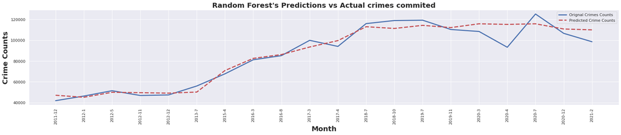

```python
# converting pyspark dataframe to pandas dataframe
rf_pred = rf_predDF.toPandas()
# parsing year and month as strings and concatenating them to form the xticks
rf_pred.time = rf_pred.year.astype("str") + "-" + rf_pred.month.astype("str")
# setting figure size
plt.figure(figsize=(30,5))
# setting and formatting the title
plt.title("Random Forest's Predictions vs Actual crimes commited",fontsize=20,fontweight="bold")
# setting and formatting the x label
plt.xlabel("Month",fontsize=20,fontweight="bold")
# setting and formatting the y label
plt.ylabel("Crime Counts",fontsize=20,fontweight="bold")
# rotating the xticks by 90 degrees so that they wont merge with each other
plt.xticks(rotation=90)
# plotting the original crimes commited in test data
plt.plot(rf_pred.time,rf_pred.crimes_commited, label = "Orignal Crimes Counts",linewidth=3,color='b')
# plotting the predicted crimes commited
plt.plot(rf_pred.time,rf_pred.prediction, label = "Predicted Crime Counts",linewidth=3,color='r',linestyle='--')
# setting up the legend
plt.legend()
plt.show()
```

Both the line plot and Normalised RMSE of 0.09 indicate that this model performed really well at predicting crime counts for unseen data. Indicating that it's a good fit

### **5.4.6 GBDT** [27]

Authors of [27-30] used Gradient boosted decision trees for forecasting crimes because GBDTs train several decision trees sequentially, with each tree trying to improve its predecessor by learning from predecessor's mistakes/residuals which is somewhat similar to what statistical models do.

```python
%%time
# using vector assembler to create a single feature which contains values of all other features
vecAssembler = VectorAssembler(inputCols=['year','month','lag1','lag2','lag3','lag4','lag5','lag6','lag7',
                                          'lag8','lag9','lag10','lag11','lag12'], outputCol="features")

# Splitting the whole pre-processed dataset into 80% train and 20% test data
(trainDF, testDF) = splitted_violent_crimes_count.randomSplit([.8, .2])
# defining gradient boosted decision tree model with inputs as features and labels
gbt = GBTRegressor(featuresCol="features",labelCol='crimes_commited')
# creating pipeline of vector assembler and GBDT model
pipeline = Pipeline(stages=[vecAssembler, gbt])
# fitting pipeline on training data
model = pipeline.fit(trainDF)
# making predictions
GBDT_predDF = model.transform(testDF)
# defining evaluator with rmse as the filter
Evaluator = RegressionEvaluator(predictionCol="prediction",labelCol="crimes_commited",metricName="rmse")
# evaluating predictions
rmse = Evaluator.evaluate(GBDT_predDF)
# finding the maximum number of crimes commited in test data
max_in_test = GBDT_predDF.agg({'crimes_commited': 'max'}).rdd.flatMap(lambda x: x).collect()
# finding the minimum number of crimes commited in test data
min_in_test = GBDT_predDF.agg({'crimes_commited': 'min'}).rdd.flatMap(lambda x: x).collect()
# finding normalised RMSE for GBDT
print(f"Normalised RMSE is {rmse/(max_in_test[0] - min_in_test[0]):.2f}\n")
```

```
Normalised RMSE is 0.07

CPU times: user 9.99 s, sys: 1.3 s, total: 11.3 s
Wall time: 28min 4s
```

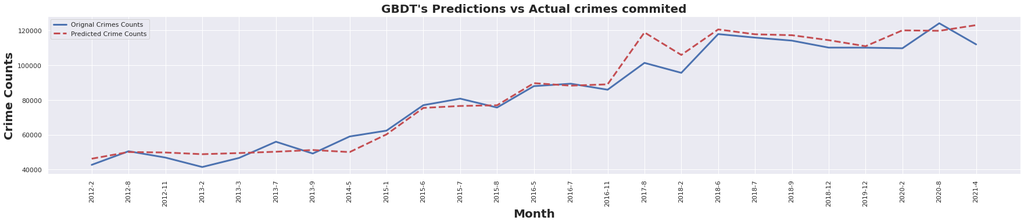

```python
# converting pyspark dataframe to pandas dataframe
gbdt_pred = GBDT_predDF.toPandas()
# parsing year and month as strings and concatenating them to form the xticks
gbdt_pred.time = gbdt_pred.year.astype("str") + "-" + gbdt_pred.month.astype("str")
# setting figure size
plt.figure(figsize=(30,5))
# setting and formatting the title
plt.title("GBDT's Predictions vs Actual crimes commited",fontsize=20,fontweight="bold")
# setting and formatting the x label
plt.xlabel("Month",fontsize=20,fontweight="bold")
# setting and formatting the y label
plt.ylabel("Crime Counts",fontsize=20,fontweight="bold")
# rotating the xticks by 90 degrees so that they wont merge with each other
plt.xticks(rotation=90)
# plotting the original crimes commited in test data
plt.plot(gbdt_pred.time,gbdt_pred.crimes_commited, label = "Orignal Crimes Counts",linewidth=3,color='b')
# plotting the predicted crimes commited
plt.plot(gbdt_pred.time,gbdt_pred.prediction, label = "Predicted Crime Counts",linewidth=3,color='r',linestyle='--')
# setting up the legend
plt.legend()
plt.show()
```

### **5.5 ARE THERE MORE FIREARM INCIDENTS PER HEAD IN BIRMINGHAM THAN ANYWHERE ELSE IN THE U.K. ?**

The following 3 queries are executed:

1. First cell sums up the total number of residents for each geography in the geography_residents table
2. Second cell counts the total number of firearm incidents for each lsoa_city in the firearm_count table
3. Third cell counts the firearm incidents per head for each lsoa_city and arranges them in descending order in the firearms_per_head table

The first row of the firearms_per_head table shows the region with the most firearm incidents per head.

```python
%%time
firearm_incidents.createOrReplaceTempView("firearm_incidents_table")
lsoa.createOrReplaceTempView("lsoa_table")

# This query counts the population of each geography
geography_residents = spark.sql('''
select
  geography,
  sum(total_residents) as total_residents
from
  lsoa_table
group by
  geography
order by
  geography
''')

# showing first 20 rows of the geography_residents dataframe
geography_residents.show(truncate=False)
```

```
+----------------------------+---------------+
|geography                   |total_residents|
+----------------------------+---------------+
|Adur                        |61182          |
|Allerdale                   |96422          |
|Amber Valley                |122309         |
|Arun                        |149518         |
|Ashfield                    |119497         |
|Ashford                     |117956         |
|Aylesbury Vale              |174137         |
|Babergh                     |87740          |
|Barking and Dagenham        |185911         |
|Barnet                      |356386         |
|Barnsley                    |231221         |
|Barrow-in-Furness           |69087          |
|Basildon                    |174497         |
|Basingstoke and Deane       |167799         |
|Bassetlaw                   |112863         |
|Bath and North East Somerset|176016         |
|Bedford                     |157479         |
|Bexley                      |231997         |
|Birmingham                  |1073045        |
|Blaby                       |93915          |
+----------------------------+---------------+
only showing top 20 rows

CPU times: user 47.1 ms, sys: 7.67 ms, total: 54.8 ms
Wall time: 3.8 s
```

```python
%%time
# This query counts the number of firearms incidents in each lsoa city
firearm_count = spark.sql('''
select
  lsoa_city,
  count(lsoa_city) as firearm_count
from
  firearm_incidents_table
group by
  lsoa_city
order by
  lsoa_city
''')

# showing the first 20 rows of firearm_count dataframe
firearm_count.show(truncate=False)
```

```
+----------------------------+-------------+
|lsoa_city                   |firearm_count|
+----------------------------+-------------+
|Adur                        |2            |
|Allerdale                   |21           |
|Amber Valley                |27           |
|Arun                        |14           |
|Ashfield                    |21           |
|Ashford                     |15           |
|Aylesbury Vale              |27           |
|Babergh                     |3            |
|Barking and Dagenham        |49           |
|Barnet                      |43           |
|Barnsley                    |63           |
|Barrow-in-Furness           |19           |
|Basildon                    |36           |
|Basingstoke and Deane       |13           |
|Bassetlaw                   |26           |
|Bath and North East Somerset|6            |
|Bedford                     |48           |
|Bexley                      |16           |
|Birmingham                  |231          |
|Blaby                       |1            |
+----------------------------+-------------+
only showing top 20 rows

CPU times: user 1.14 s, sys: 118 ms, total: 1.26 s
Wall time: 3min 25s
```

```python
%%time
# This query returns the firearm incidents per head arranged in descending order
geography_residents.createOrReplaceTempView("geography_residents_table")
firearm_count.createOrReplaceTempView("firearm_count_table")
firearms_per_head = spark.sql('''
select
  fct.lsoa_city as REGION,
  fct.firearm_count,
  grt.total_residents,
  fct.firearm_count / grt.total_residents as INCIDENTS_per_HEAD
from
  geography_residents_table as grt
  inner join firearm_count_table as fct on grt.geography = fct.lsoa_city
order by
  INCIDENTS_per_HEAD desc
''')

# Since firearms_per_head was ordered by incidents_per_head in descending order, the first row indicates the maximum
firearms_per_head.show(20,False)
```

```
+------------------+-------------+---------------+---------------------+
|REGION            |firearm_count|total_residents|INCIDENTS_per_HEAD   |
+------------------+-------------+---------------+---------------------+
|City of London    |17           |7375           |0.0023050847457627118|
|Westminster       |126          |219396         |5.743039982497402E-4 |
|Derby             |128          |248752         |5.145687270856114E-4 |
|Norwich           |65           |132512         |4.905216131369235E-4 |
|Nottingham        |148          |305680         |4.841664485736718E-4 |
|Darlington        |50           |105564         |4.736463188208101E-4 |
|Lambeth           |138          |303086         |4.55316312861696E-4  |
|Stoke-on-Trent    |112          |249008         |4.497847458716186E-4 |
|Kingston upon Hull|115          |256406         |4.485074452235907E-4 |
|Scarborough       |47           |108793         |4.320130890774223E-4 |
|Watford           |39           |90301          |4.3188890488477427E-4|
|Islington         |89           |206125         |4.3177683444511824E-4|
|Torbay            |55           |130959         |4.199787719820707E-4 |
|Plymouth          |105          |256384         |4.0954193709435847E-4|
|Lincoln           |38           |93541          |4.06238975422542E-4  |
|Hackney           |100          |246270         |4.0605839119665406E-4|
|Tower Hamlets     |103          |254096         |4.053586046218752E-4 |
|Thanet            |52           |134186         |3.8752179810114316E-4|
|Doncaster         |117          |302402         |3.8690220302775775E-4|
|Luton             |77           |203201         |3.7893514303571343E-4|
+------------------+-------------+---------------+---------------------+
only showing top 20 rows

CPU times: user 1.31 s, sys: 159 ms, total: 1.47 s
Wall time: 3min 22s
```

The horizontal barplot was chosen in particular to statistically analyse the firearm incidents per head because it is effective for visualising ranked data and avoids merging of county names on the x-axis.

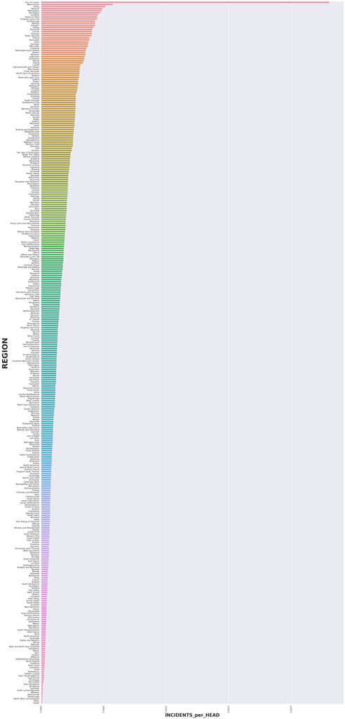

```
CPU times: user 4.01 s, sys: 327 ms, total: 4.34 s
Wall time: 2min 46s
```

```python
%%time
# converting firearm incidents per head pyspark dataframe to pandas dataframe for visualisation
fph = firearms_per_head.toPandas()
# setting the figure size
plt.figure(figsize = (30,70))
# setting and formatting x label
plt.xlabel("INCIDENTS_per_HEAD",fontsize = 25, fontweight="bold")
# setting and formatting y label
plt.ylabel("REGION",fontsize = 40, fontweight="bold")
# rotating xticks by 90 degrees to prevent county names from merging from each other
plt.xticks(rotation=90)
# plotting horizontal barplot to make the chart fit well in the frame and prevent county names from merging with each other
sns.barplot(data=fph, y="REGION", x="INCIDENTS_per_HEAD")
plt.show()
```

**The barplot looks like a postive/right skewed distribution and explicitly depicts that "City of London" had the most firearm incidents per head, disproving claim 2**

```python
# What is Birmingham's rank in terms of firearms incidents per head ?
fph[fph.REGION == "Birmingham"]
```

|  | REGION | firearm_count | total_residents | INCIDENTS_per_HEAD |
| --- | --- | --- | --- | --- |
| 87 | Birmingham | 231 | 1073045 | 0.00021528 |

```python
# Which county has highest number of firearm incidents ?
descending_crime_counts = fph.sort_values("firearm_count",ascending=False)
descending_crime_counts.head(1)
```

|  | REGION | firearm_count | total_residents | INCIDENTS_per_HEAD |
| --- | --- | --- | --- | --- |
| 87 | Birmingham | 231 | 1073045 | 0.00021528 |

Birmingham has the highest number of firearm incidents, but ranks 88th in terms of firearm incidents per head

### **5.6 ARE FIREARM INCIDENTS CLOSELY ASSOCIATED WITH DRUG OFFENCES ?**

The following cell involves 3 queries:

1. The first cell counts the number of drug offenses that happened at the same location (lsoa_code) and at the same time (month)
2. The second cell does the same for firearm incidents.
3. The third cell joins the tables from the first two cells to obtain the number of drug and firearm incidents that happened at the same location (lsoa_code) and at the same time (month).

The drug_counts and firearm_counts were vectorized, and spearman [32] and pearson [31] correlation was computed between them.

```python
%%time
# filtering out drug offences from all crimes and counting the number of drug offences that happened at the
# same place (lsoa_code) at the same time (month)
all_crimes.createOrReplaceTempView("all_crimes_table")
drug_offences.createOrReplaceTempView("drug_offences_table")
drug_counts = spark.sql('''
select
  month,
  lsoa_code,
  count(*) as drug_count
from
  drug_offences_table
group by
  month,
  lsoa_code
''')

# dropping nulls if any
drug_counts = drug_counts.na.drop("any")

# showing first 20 rows of drug_offences dataframe
drug_counts.show(truncate=False)
```

```
+-------+---------+----------+
|month  |lsoa_code|drug_count|
+-------+---------+----------+
|2013-09|E01017073|1         |
|2017-10|E01023026|1         |
|2012-11|E01017192|1         |
|2013-03|E01016337|2         |
|2019-08|E01003325|1         |
|2018-07|E01033420|3         |
|2015-03|E01003127|1         |
|2018-11|E01001932|3         |
|2013-09|E01001874|3         |
|2014-10|E01001955|3         |
|2012-03|E01004306|8         |
|2018-08|E01000092|2         |
|2021-01|E01003562|2         |
|2019-09|E01000138|1         |
|2013-01|E01021318|8         |
|2019-06|E01004408|3         |
|2017-01|E01009499|2         |
|2016-02|E01009583|2         |
|2013-11|E01009943|1         |
|2015-12|E01010316|2         |
+-------+---------+----------+
only showing top 20 rows

CPU times: user 10.7 s, sys: 1.46 s, total: 12.1 s
Wall time: 29min 59s
```

```python
%%time
# filtering firearm incidents from all crimes and counting the number of firearm incidents that happened at the
# same place (lsoa_code) at the same time (month)
firearm_incidents.createOrReplaceTempView("firearm_incidents_table")
firearm_counts = spark.sql('''
select
  month,
  lsoa_code,
  count(*) as fire_count
from
  firearm_incidents_table
group by
  month,
  lsoa_code
''')

# dropping nulls if any
firearm_counts = firearm_counts.na.drop("any")

# showing first 20 rows of firearm_offences dataframe
firearm_counts.show(truncate=False)
```

```
+-------+---------+----------+
|month  |lsoa_code|fire_count|
+-------+---------+----------+
|2017-03|E01011268|1         |
|2014-02|E01024076|1         |
|2019-02|E01029604|1         |
|2016-10|E01017509|1         |
|2017-03|E01014582|1         |
|2013-08|E01033639|1         |
|2016-04|E01017333|1         |
|2015-02|E01000434|1         |
|2015-09|E01033008|1         |
|2018-11|E01033703|1         |
|2013-05|E01033265|1         |
|2018-03|E01033164|1         |
|2019-01|E01008757|1         |
|2015-08|W01001696|1         |
|2019-01|E01002401|1         |
|2019-03|E01012683|1         |
|2015-03|E01003030|1         |
|2015-07|E01002467|1         |
|2017-11|E01032867|1         |
|2017-07|E01011229|1         |
+-------+---------+----------+
only showing top 20 rows

CPU times: user 1.09 s, sys: 107 ms, total: 1.2 s
Wall time: 3min 2s
```

```python
%%time
# joining drug offences counts and firearm incidents counts that happend at the same place (lsoa_code) at the same time (month)
drug_counts.createOrReplaceTempView("drug_counts_table")
firearm_counts.createOrReplaceTempView("firearm_counts_table")
drug_fire = spark.sql('''
select
  drug_count,
  fire_count
from
  drug_counts_table as dct
  inner join firearm_counts_table as fct on dct.month = fct.month and dct.lsoa_code = fct.lsoa_code
''')

# showing first 20 rows of drug_fire dataframe
drug_fire.show(truncate=False)
```

```
+----------+----------+
|drug_count|fire_count|
+----------+----------+
|2         |1         |
|2         |1         |
|26        |1         |
|4         |1         |
|1         |1         |
|6         |1         |
|14        |1         |
|10        |1         |
|1         |1         |
|1         |1         |
|2         |1         |
|2         |1         |
|3         |1         |
|7         |1         |
|2         |1         |
|1         |1         |
|3         |1         |
|1         |1         |
|1         |1         |
|1         |1         |
+----------+----------+
only showing top 20 rows

CPU times: user 1.91 s, sys: 206 ms, total: 2.11 s
Wall time: 5min 39s
```

```python
%%time
# Vectorize dataframe
vector_col = "corr_features"
assembler = VectorAssembler(inputCols=drug_fire.columns, outputCol=vector_col)
df_vector = assembler.transform(drug_fire).select(vector_col)
df_vector.show(truncate=False)
```

```
+-------------+
|corr_features|
+-------------+
|[2.0,1.0]    |
|[2.0,1.0]    |
|[26.0,1.0]   |
|[4.0,1.0]    |
|[1.0,1.0]    |
|[6.0,1.0]    |
|[14.0,1.0]   |
|[10.0,1.0]   |
|[1.0,1.0]    |
|[1.0,1.0]    |
|[2.0,1.0]    |
|[2.0,1.0]    |
|[3.0,1.0]    |
|[7.0,1.0]    |
|[2.0,1.0]    |
|[1.0,1.0]    |
|[3.0,1.0]    |
|[1.0,1.0]    |
|[1.0,1.0]    |
|[1.0,1.0]    |
+-------------+
only showing top 20 rows

CPU times: user 2.07 s, sys: 261 ms, total: 2.33 s
Wall time: 5min 45s
```

```python
%%time
# Get Pearson correlation matrix
matrix = Correlation.corr(df_vector, vector_col)
cor_np = matrix.collect()[0][matrix.columns[0]].toArray()
# pretty printing the pearson correlation matrix
pearson_corr_columns=['drug_count','fire_count']
print('\t'.join([col[0:10] for col in pearson_corr_columns]))
print("\n".join("\t".join(["{0:.2f}".format(num) for num in list(subList)]) for subList in list(cor_np)))
```

```
drug_count	fire_count
1.00	0.14
0.14	1.00
CPU times: user 2.51 s, sys: 355 ms, total: 2.87 s
Wall time: 6min 27s
```

```python
%%time
# get Spearman correlation matrix
smatrix = Correlation.corr(df_vector, vector_col, method='spearman')
scor_np = smatrix.collect()[0][smatrix.columns[0]].toArray()
# pretty printing the spearman correlation matrix
spearman_corr_columns=['drug_count','fire_count']
print('\t'.join([col[0:10] for col in spearman_corr_columns]))
print("\n".join("\t".join(["{0:.2f}".format(num) for num in list(subList)]) for subList in list(scor_np)))
```

```
drug_count	fire_count
1.00	0.13
0.13	1.00
CPU times: user 2.63 s, sys: 318 ms, total: 2.95 s
Wall time: 6min 36s
```

These correlations were visualized using heatmap because by-default the computed correlations were just numbers and it was not clear exactly which two variables these numbers corresponded to, but heatmap made it visually much more appealing by countering this issue.

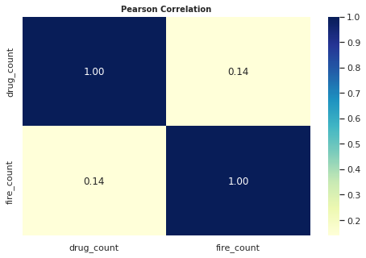

```
CPU times: user 374 ms, sys: 141 ms, total: 516 ms
Wall time: 1.29 s
```

```python
%%time
# creating a dataframe for pearson correlation matrix with corresponding column names and indexes
pearson_corr = pd.DataFrame(cor_np, columns=['drug_count','fire_count'],index=['drug_count','fire_count'])
# setting figure size
plt.figure(figsize=(8,5))
# setting and formatting title
plt.title("Pearson Correlation", fontsize = 10, fontweight='bold')
# plotting heatmap to visualise correlations between corresponding variables
sns.heatmap(pearson_corr, annot=True, fmt=".2f", cmap="YlGnBu")
plt.show()
```

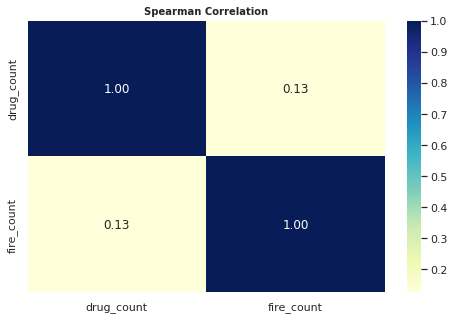

```
CPU times: user 279 ms, sys: 120 ms, total: 399 ms
Wall time: 310 ms
```

```python
%%time
# creating a dataframe for spearman correlation matrix with corresponding column names and indexes
spearman_corr = pd.DataFrame(scor_np, columns=['drug_count','fire_count'],index=['drug_count','fire_count'])
# setting figure size
plt.figure(figsize=(8,5))
# setting and formatting title
plt.title("Spearman Correlation", fontsize = 10,fontweight='bold')
# plotting heatmap to visualise correlations between corresponding variables
sns.heatmap(spearman_corr, annot=True, fmt=".2f", cmap="YlGnBu")
plt.show()
```

Spearman and Pearson correlation resulted in correlation coefficeints of 0.13 and 0.14 respecitively, this means that there is a slight tendency for an increase in one type of incident/offence to be associated with a corresponding increase in the other type of incident/offence, but the relationship is very weak. This indicates that **drug offences are not associated with firearm incidents, disproving claim 3**.

## **6. DETAILED ANALYSIS AND CONSIDERATION OF THE APPROPRIATENESS OF THE SOLUTION FOR THE INITIAL PROBLEM**

The disadvantage of using polynomial regression was that it was prone to overfit with higher degree polynomials and to underfit with lower degree polynomials. Moving average uses mean which makes it sensitive to outliers and both polynomial regression and moving average overlook the complex relationships in data by approximating them. With barplot sometimes it can be challenging to interpret the trend if the rate of change in crime counts is relatively small. Amongst all the visualisations, KDE plot seemed most appropriate for visualizing trend because it comes with an advantage of forecasting the joint probability density/trend for future months and unlike other visualisations it is not sensitive to outliers and does not approximates or overlooks complex relationships in the original time series data. It's only limitation can be that it can be slightly difficult to interpret because it is a top view of a 3D bell curve.

From section 3.5 it can be observed that latitude, longitude and lsoa_code all had same number of nulls. Using trimmed postcodes as region indicator would have involved more queries to make joins for replacing latitude and longitude which would account for additional computational cost and possibly more nulls which when dropped, could result in loss of data which is why postcodes approach was not implemented. Thefore, lsoa_city column was used as the region indicator for verifying claim 2 as it was already present in the firearm_incidents dataframe, was associated with the geography column in the lsoa dataframe, had the same number of nulls as the latitude and longitude columns and allowed for larger areas to be considered when summing up total residents and counting firearm incidents.

Using lsoa_code as a location indicator for claim 3 was better than latitude and longitude as it accounts for the same area and requires less computation cost due to involving fewer columns in grouping data and joining tables. Scatter plot could only show the direction of relationship/association and is not good at visualising the strength of especially non-linear relationships which is why it was not implemented. Whereas, correlation can also involve monotonic relationships using ranked values to quantify both the direction and the degree/strength to which two variables are related. Therefore, correlation made more sense to find association between drug offences and firearm incidents. The main drawback/limitation of correlation is that it cannot tell us which variable was the source of the association and which one was the effect. Even when it informs us that there is a relation, it omits to explain why it exists.

## **7. EVALUATION AND CONCLUSION**

Based on multiple visualisations and machine learning methods, it is concluded that violent crimes are increasing, but the trend has been almost stable from 2019 to 2021 due to COVID-19 and less aggression by the police **[33,34]**.

Using the LSOA approach, which was better than the postcodes approach both in terms of computational cost and generating larger area, it was concluded that claim 2 was wrong and "City of London" had the highest firearm incidents per head in the UK, despite Birmingham having the most firearm incidents. The possible reason for this can be the concentration of people and resources in "City of London". Additionally, socio-economic factors, such as the huge gap between the rich and the poor in London as compared to any other place in UK can also account for this research finding.

Pearson and Spearman correlations which resulted in correlation co-efficients of 0.14 and 0.13 respectively, were utilised to analyse the relationship between firearm incidents and drug offences, and it was concluded that they are not associated, disproving claim 3. There could be other factors that are contributing to both types of offenses which needs to be further researched.

The results of this investigation make it very evident that violent crimes are on the rise. To prevent this trend from continuing in future, the police should concentrate on repeat victims, high volume criminals, and firearm hotspots identified (in section 5.5 of this research) in order to stop this trend from continuing. Goverment should limit access to firearms which can also help to reduce the number of violent crimes committed with guns. Police should work closely with community members to identify and address potential sources of crime and conflict which can help to build trust between the police and the community, which will make it more likely that people will report crimes and cooperate with investigations. Finally, the police should give priority to instances that result in the greatest amount of harm while making sure that attempts to lower demand do not have any unintended negative effects on the general public.

## **8. REFERENCES**

1. G. Garcıa, J. Silveira, J. Poco, A. Paiva, M.B. Nery, C.T. Silva, S. Adorno and L.G.Nonato, “Crimanalyzer: Understanding crime patterns in sao paulo,” IEEE transactions on visualization and computer graphics, vol 4, pp. 2313-2328, 2019
2. G. Borowik, Z.M. Wawrzyniak and P. Cichosz, “Time series analysis for crime forecasting”, pp. 1-10, 2018.
3. A. Jain and V. Bhatnagar, "Crime data analysis using pig with Hadoop", Procedia Computer Science, vol. 78, pp. 571–578, 2016.
4. V. Melnykov, X. Zhu, "Studying crime trends in the USA over the years 2000–2012". Adv Data Anal Classif, vol. 13, pp. 325–341, 2019. DOI: 10.1007/s11634-018-0326-1
5. A.A. Biswas and S. Basak, "Forecasting the Trends and Patterns of Crime in Bangladesh using Machine Learning Model," Intelligent Communication and Computational Techniques, vol 2, pp. 114-118, 2019, doi: 10.1109/ICCT46177.2019.8969031.
6. M. Lofstrom, S. Raphael, "Public safety realignment and crime rates in California". pp. 1-24, 2011.
7. SP. Chainey, "Examining the influence of cell size and bandwidth size on kernel density estimation crime hotspot maps for predicting spatial patterns of crime". Bulletin of the Geographical Society of Liege , vol. 60, pp. 7-19, 2013
8. X. Chen, Y. Cho and S.Y. Jang, "Crime prediction using Twitter sentiment and weather," Systems and Information Engineering Design Symposium, pp. 63-68, 2015, doi: 10.1109/SIEDS.2015.7117012.
9. T. Cheng and D. Williams. "Space-time analysis of crime patterns in central London". Remote Sensing and Spatial Information Sciences, vol. 39, pp.47-52, 2012
10. P.R. Boppuru, K. Ramesha, “Geospatial Crime Analysis to Determine Crime Density Using Kernel Density Estimation for the Indian Context”, Journal of Computational and Theoretical Nanoscience, pp. 1-14, February 2020.
11. T. Allen & G. Buckner, Expanding the Role of the Bar Chart in Representing Crime Data, CHANCE, vol. 5, 54-59, 1992, DOI: 10.1080/09332480.1992.10554987
12. A. Bala, S. Bawa, M.S. Lugga, O.G. Ajayi. "Geospatial Information System for Crime Analysis and Crime Zone Identification - Case Study of Katsina, Nigeria". Journal of Multidisciplinary Engineering Science and Technology. vol 2, pp. 1-15, 2015
13. N.B. Anuar, B.W. Yap, "Data Visualization of Violent Crime Hotspots in Malaysia". Communications in Computer and Information Science, vol 937. pp. 1-16, 2019. DOI: 10.1007/978-981-13-3441-2_27
14. J.L. Ocando. “Visualising Crime Statistics. In: Crime Statistics in the News”. Palgrave Macmillan, Crime Statistics in the News, vol 1. pp 135–149, 2017
15. M. Feng, J. Zheng, J. Ren, A. Hussain, X. Li, Y. Xi, and Q. Liu. "Big data analytics and mining for effective visualization and trends forecasting of crime data". IEEE Access, vol. 7, pp.106111-106123, 2019
16. A.M. Razip, A. Malik, S. Afzal, M. Potrawski, R. Maciejewski, Y. Jang, N. Elmqvist and D.S. Ebert. "A mobile visual analytics approach for law enforcement situation awareness". Pacific Visualization Symposium, vol 4, pp. 169-176, 2014
17. M. Xie. "Area differences and time trends in crime reporting: Comparing New York with other metropolitan areas". Justice Quarterly, vol. 31, pp.43-73, 2014
18. Y.W. Cheung & K.S. Lai. "Lag order and critical values of the augmented Dickey–Fuller test". Journal of Business & Economic Statistics, vol. 3, pp.277–280, 1995.
19. S.J. Koopman, J. Durbin. "Time Series Analysis by State Space Methods", vol 2, 3 May 2012. doi: 10.1093/acprof:oso/9780199641178.001.0001
20. N. Tasnim, I.T. Imam, and M.M.A Hashem. "A Novel Multi-Module Approach to Predict Crime Based on Multivariate Spatio-Temporal Data Using Attention and Sequential Fusion Model". IEEE Access, vol. 10, pp.48009-48030, 2022
21. T.H. Noor, A.M. Almars, M. Alwateer, M. Almaliki, I. Gad, and E.S. Atlam. "SARIMA: A Seasonal Autoregressive Integrated Moving Average Model for Crime Analysis in Saudi Arabia". Electronics, vol 11, pp 3986-3407. 2022
22. H. Bozdogan, "Model selection and Akaike's Information Criterion (AIC): The general theory and its analytical extensions". Psychometrika vol. 52, 345–370, 1987, doi: 10.1007/BF02294361
23. T.K. Ho, "Random decision forests". In Proceedings of 3rd international conference on document analysis and recognition. pp. 278–282, 1995.
24. Z. Xia, K. Stewart, and J. Fan. "Incorporating space and time into random forest models for analyzing geospatial patterns of drug-related crime incidents in a major us metropolitan area". Computers, environment and urban systems, vol 87, pp.101599-101622, 2021
25. G. Oh, J. Song, H. Park, and C. Na. "Evaluation of random forest in crime prediction: Comparing three-layered random forest and logistic regression". Deviant Behavior, pp.1-14, 2021
26. T. Arora, M. Sharma, and S.K. Khatri. "Detection of cyber crime on social media using random forest algorithm". Environment and Intelligent Control, vol 61, pp. 47-51, 2019
27. T. Chen, & C. Guestrin, "XGBoost: A Scalable Tree Boosting System". Discovery and Data Mining. vol 12, pp. 785–794, 2016, DOI: 10.1145/2939672.2939785.
28. R. Rawat, V. Mahor, S. Chirgaiya, R.N. Shaw, and A. Ghosh. "Analysis of darknet traffic for criminal activities detection using TF-IDF and light gradient boosted machine learning algorithm". In Innovations in electrical and electronic engineering, vol 21, pp. 671-681. 2021
29. A. Ippolito, and A.C.G. Lozano. "Sammon Mapping-Based Gradient Boosted Trees for Tax Crime Prediction in the City of São Paulo". In International Conference on Enterprise Information Systems, vol. 34, pp. 293-316, 2021
30. W. Safat, S. Asghar, and S.A. Gillani. "Empirical analysis for crime prediction and forecasting using machine learning and deep learning techniques". IEEE Access, vol 9, pp. 70080-70094, 2021
31. J. Benesty et al., "Pearson correlation coefficient". In Noise reduction in speech processing. Springer, pp. 37–40, 2009
32. Z.H. Zar, "Spearman rank correlation". Encyclopedia of Biostatistics, 2005.
33. D.S. Abrams, “COVID and crime: An early empirical look”, Journal of Public Economics, vol. 194, pp. 104344 – 104366, 2021
34. L. Liu, J. Chang, D. Long, and H. Liu. "Analyzing the Impact of COVID-19 Lockdowns on Violent Crime" International Journal of Environmental Research and Public Health, vol. 19, 2022